# Problem Set 3

Author

Your Name

Published

November 1, 2026

**GitHub repo:** https://github.com/HaydenRAllen/ec422_ps3_allen.git

**Time and Tsibbles** can_gas comes from Canadian gas production data, at a monthly frequency, and the key/index are the months retail_ts comes from the U.S. Census Bureau’s monthly retail trade survey, at a monthly frequency, and the key/index are the months

```
# A tibble: 182 × 2
      Month avg_volume
      <mth>      <dbl>
 1 1990 Jan       12.5
 2 1990 Feb       11.2
 3 1990 Mar       11.6
 4 1990 Apr       11.1
 5 1990 May       11.0
 6 1990 Jun       10.1
 7 1990 Jul       10.6
 8 1990 Aug       10.5
 9 1990 Sep       10.3
10 1990 Oct       12.0
# ℹ 172 more rows
```

```
# A tsibble: 6 x 4 [1M]
     Month Volume next_month same_month_last_year
     <mth>  <dbl>      <mth>                <mth>
1 1990 Jan   12.5   1990 Feb             1989 Jan
2 1990 Feb   11.2   1990 Mar             1989 Feb
3 1990 Mar   11.6   1990 Apr             1989 Mar
4 1990 Apr   11.1   1990 May             1989 Apr
5 1990 May   11.0   1990 Jun             1989 May
6 1990 Jun   10.1   1990 Jul             1989 Jun
```

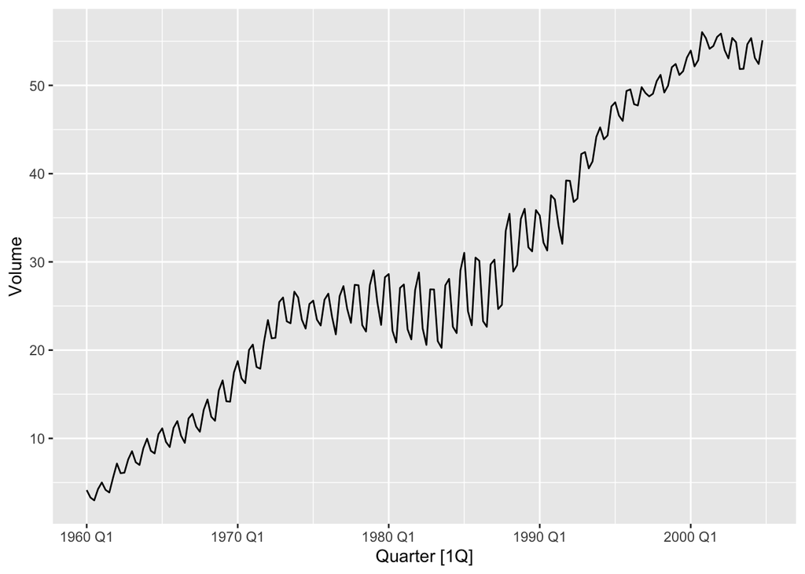

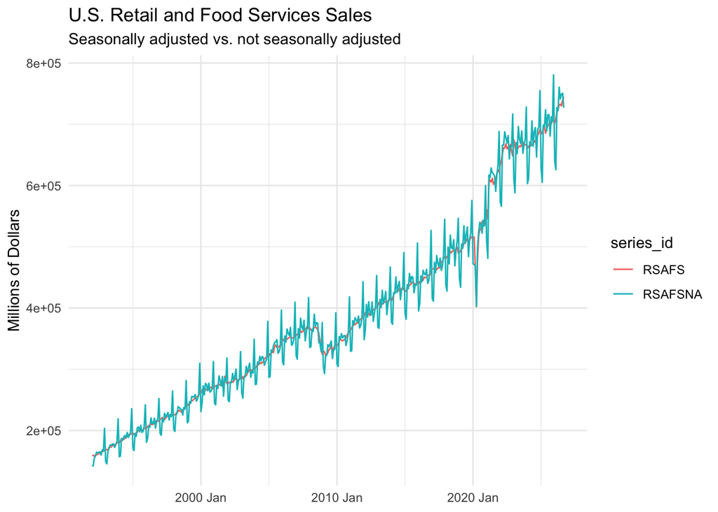

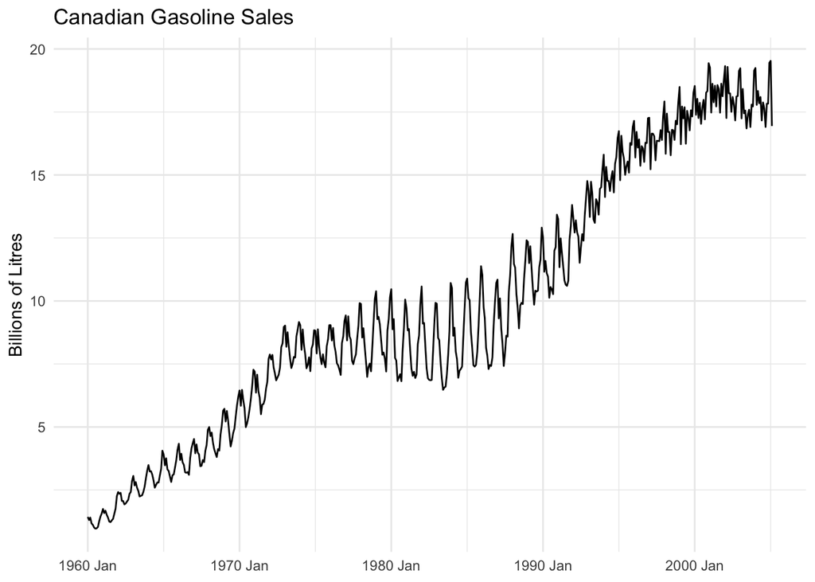

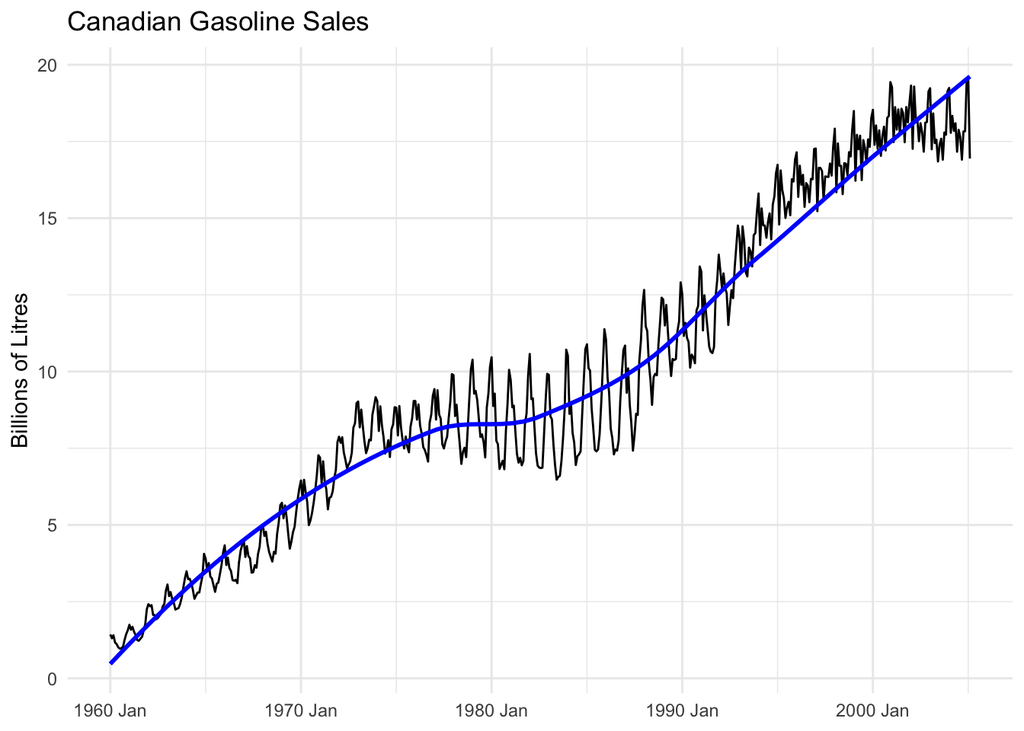

#2.7d I added geom_smooth to the plot to show the trend more clearly. The trend shows a general increase in gasoline sales over time

**Transformations**

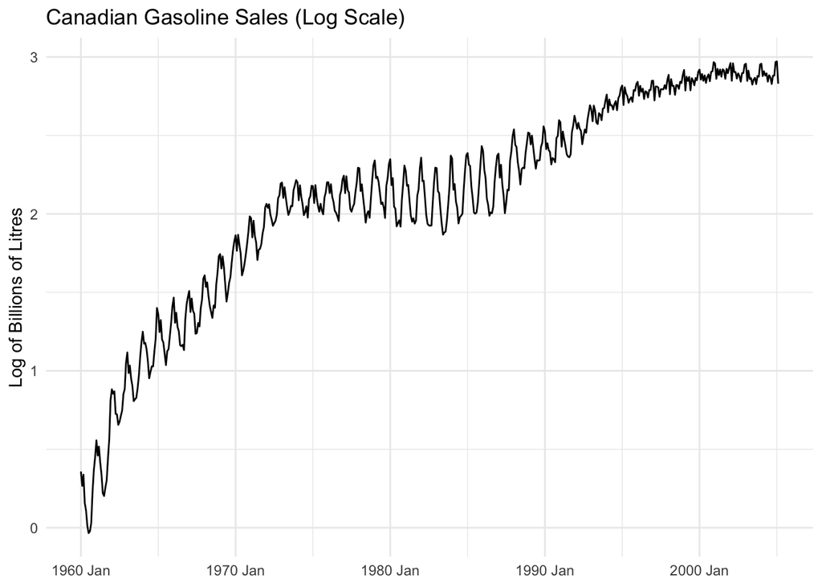

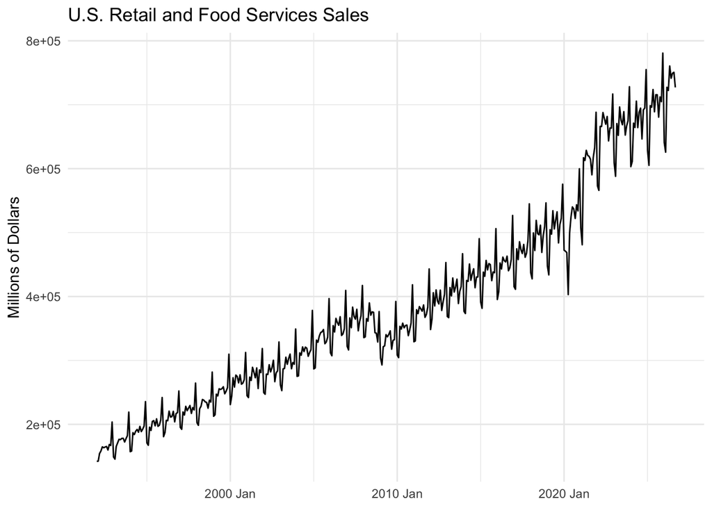

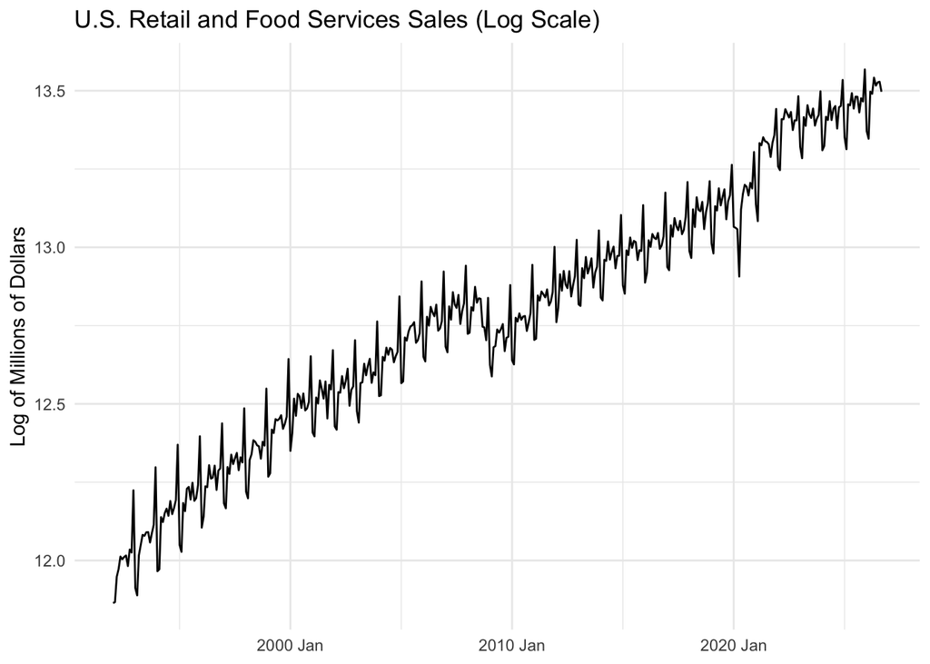

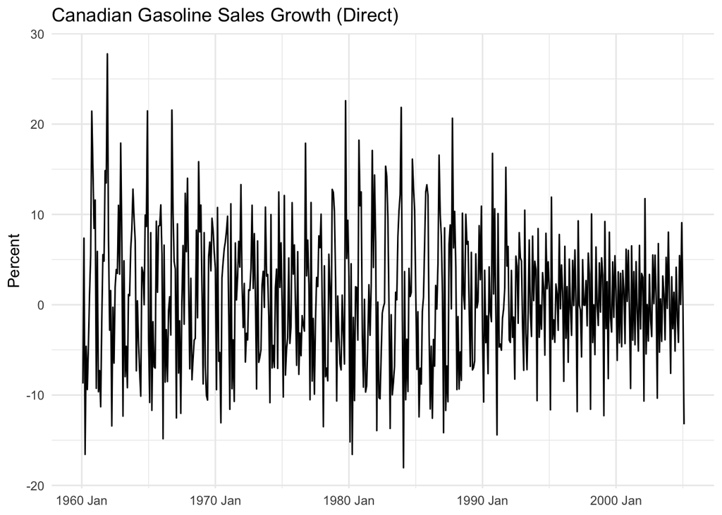

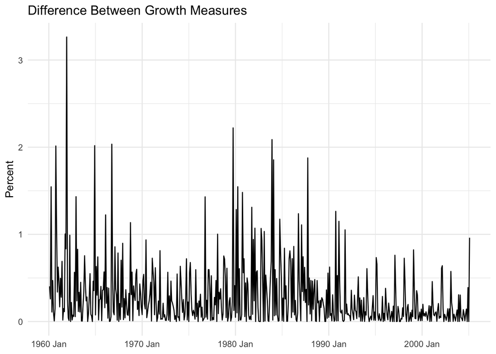

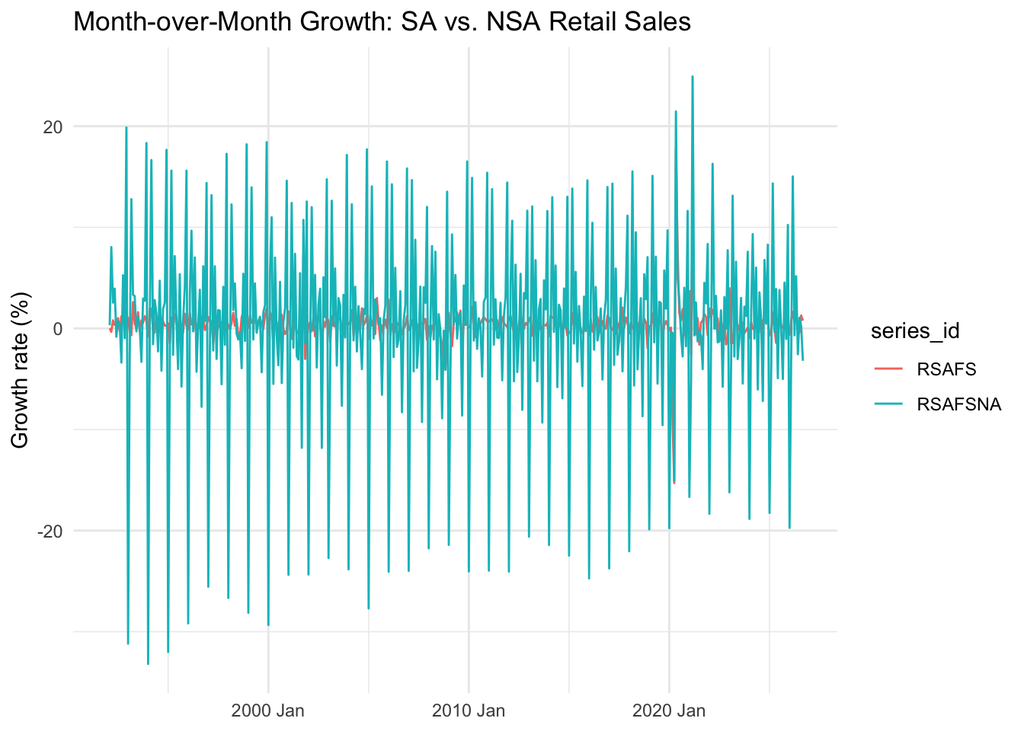

#3.1a The swings grow from 1960 to 1985, then they start to decrease.

#3.1b The shape changed to a typical logarithmic curve. The seasonal swings are less pronounced in the log graph, but still noticeable. I don’t think the log transformation is a good idea. The only noticeable difference is the shape of the trend.

#3.1c The case for logging this series is stronger because it becomes more linear than when logging the other series.

#3.2 The log difference approximation is more appropriate for this series because it is less affected by the large swings in the data.

#3.3 The adjusted series is much smoother and has less extreme swings. The not adjusted data is noisier because it has more variation and has the seasonal drop every year.

**Seasonality**

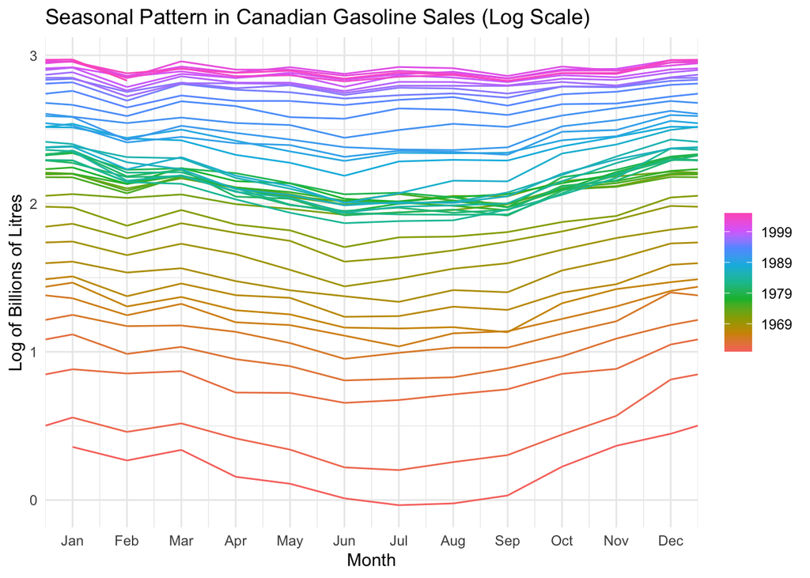

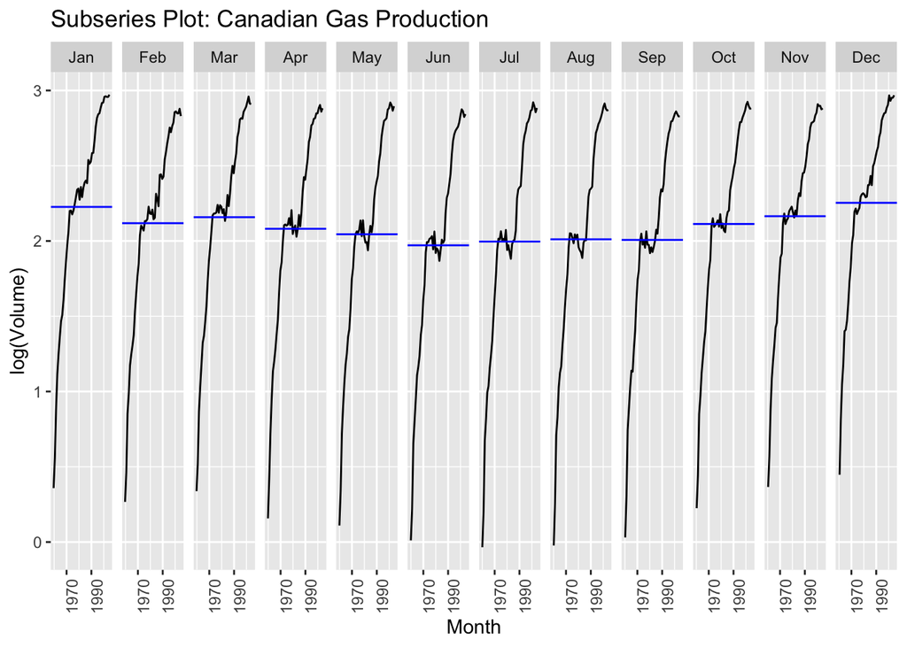

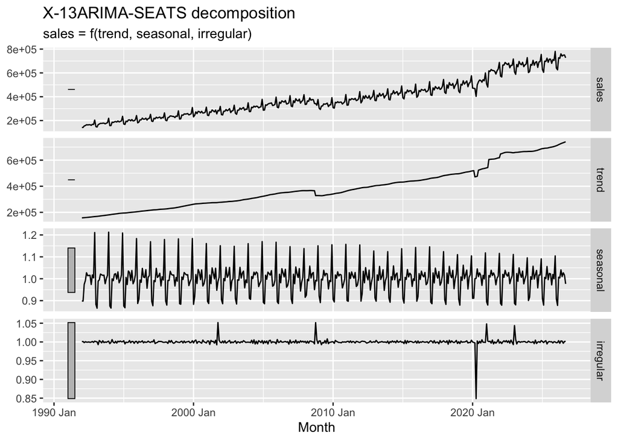

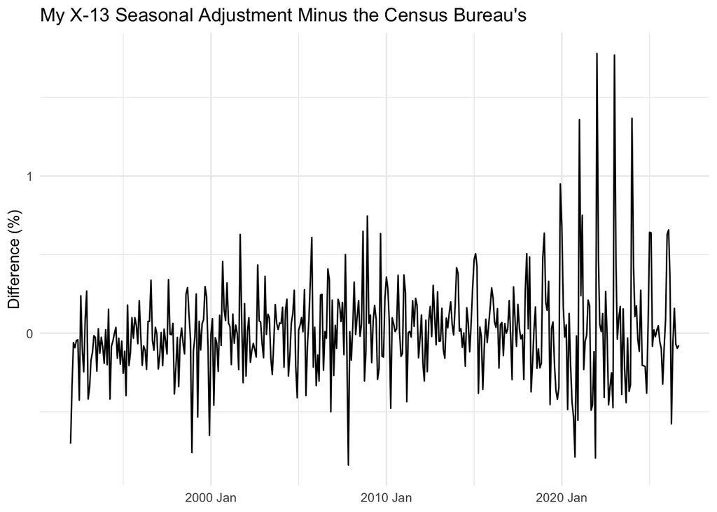

```
Series: log_volume
Model: TSLM

Residuals:
      Min        1Q    Median        3Q       Max
-0.985307 -0.096451 -0.004525  0.131639  0.470564

Coefficients:
                 Estimate Std. Error t value Pr(>|t|)
(Intercept)     1.150e+00  4.142e-02  27.761  < 2e-16 ***
trend()         3.973e-03  6.886e-05  57.692  < 2e-16 ***
season()year2  -1.121e-01  5.229e-02  -2.144  0.03245 *
season()year3  -5.238e-02  5.258e-02  -0.996  0.31963
season()year4  -1.334e-01  5.258e-02  -2.537  0.01146 *
season()year5  -1.738e-01  5.258e-02  -3.305  0.00101 **
season()year6  -2.512e-01  5.258e-02  -4.777 2.30e-06 ***
season()year7  -2.300e-01  5.258e-02  -4.374 1.47e-05 ***
season()year8  -2.193e-01  5.258e-02  -4.170 3.56e-05 ***
season()year9  -2.274e-01  5.258e-02  -4.325 1.83e-05 ***
season()year10 -1.253e-01  5.258e-02  -2.383  0.01753 *
season()year11 -7.781e-02  5.258e-02  -1.480  0.13956
season()year12  7.202e-03  5.258e-02   0.137  0.89111
---
Signif. codes:  0 '***' 0.001 '**' 0.01 '*' 0.05 '.' 0.1 ' ' 1

Residual standard error: 0.2508 on 529 degrees of freedom
Multiple R-squared: 0.8652, Adjusted R-squared: 0.8622
F-statistic:   283 on 12 and 529 DF, p-value: < 2.22e-16
```

| term | estimate | std.error | statistic | p.value |
| --- | --- | --- | --- | --- |
| (Intercept) | 1.150 | 0.041 | 27.761 | 0.000 |
| trend() | 0.004 | 0.000 | 57.692 | 0.000 |
| season()year2 | -0.112 | 0.052 | -2.144 | 0.032 |
| season()year3 | -0.052 | 0.053 | -0.996 | 0.320 |
| season()year4 | -0.133 | 0.053 | -2.537 | 0.011 |
| season()year5 | -0.174 | 0.053 | -3.305 | 0.001 |
| season()year6 | -0.251 | 0.053 | -4.777 | 0.000 |
| season()year7 | -0.230 | 0.053 | -4.374 | 0.000 |
| season()year8 | -0.219 | 0.053 | -4.170 | 0.000 |
| season()year9 | -0.227 | 0.053 | -4.325 | 0.000 |
| season()year10 | -0.125 | 0.053 | -2.383 | 0.018 |
| season()year11 | -0.078 | 0.053 | -1.480 | 0.140 |
| season()year12 | 0.007 | 0.053 | 0.137 | 0.891 |

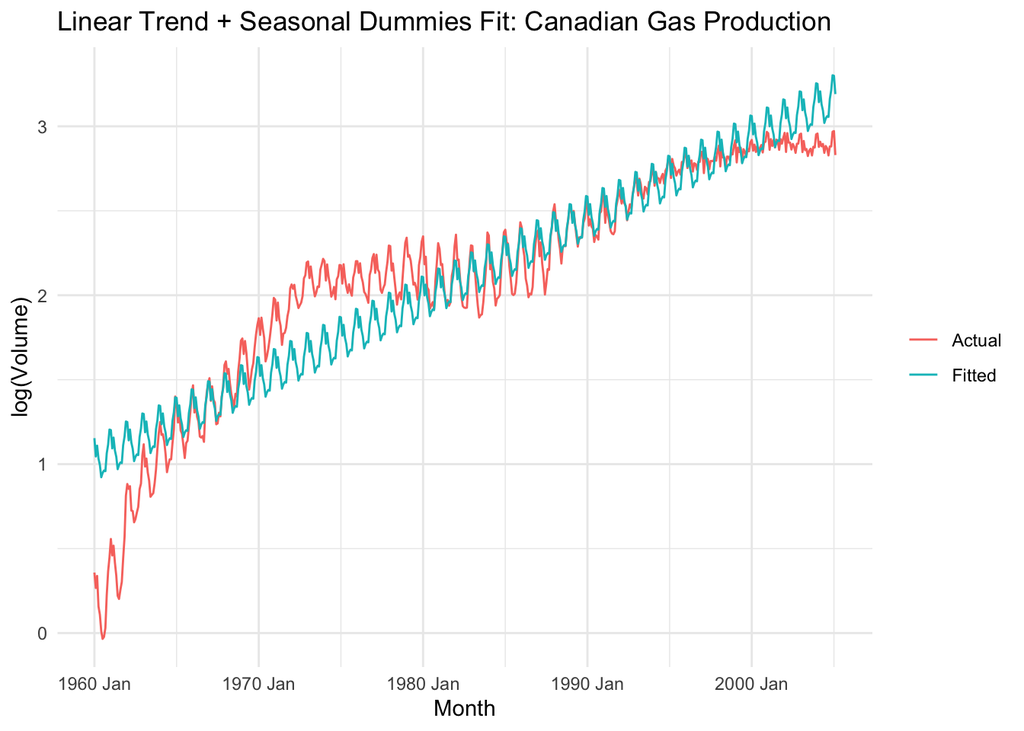

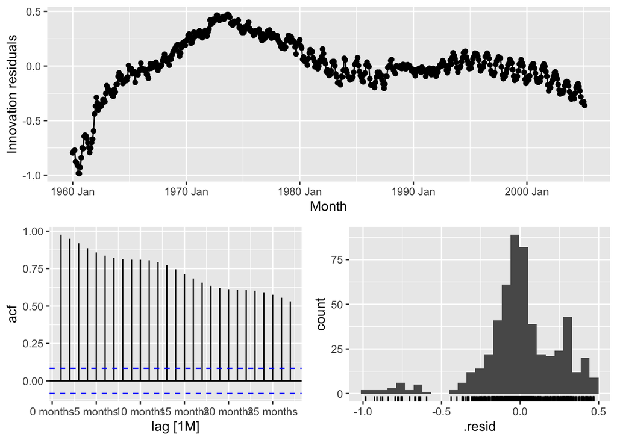

```
# A tibble: 1 × 3
  .model                                lb_stat lb_pvalue
  <chr>                                   <dbl>     <dbl>
1 TSLM(log_volume ~ trend() + season())   7774.         0
```

#4.1b The seasonally adjusted series has a much smoother line and trend compared to the NSA series. You can see the variation by the amount of dips in the NSA data.

#4.1c I can see a seasonal decline starting in the Spring, continuing through the Summer, then a rise in the Fall, and then declining again in the winter. This makes sense because of things such as heating a house during the cold months

#4.3a The month with the largest seasonal factor seems to be December. It is roughly 0.2 over the trend and the size of the swings seem to decrease over time.

#4.3b The appear to be fairly similar. The big difference is 2020 to 2023.

#4.4a The estimated average monthly growth rate of gas production is 0.4% The month with the most significant seasonal effect is June

#4.4b #the tracks fit the actual series not well seeing as the actual #line is not linear

#4.4c The residuals do not look like white noise. The p value tells us that we reject the null hypothesis of no autocorrelation

**Forecast Evaluation**

```
# A tibble: 2 × 4
  .model .type   MAE  RMSE
  <chr>  <chr> <dbl> <dbl>
1 snaive Test  0.562 0.702
2 tslm   Test  4.01  4.36
```

```
    Diebold-Mariano Test

data:  errs$snaiveerrs$tslm
DM = -31.278, Forecast horizon = 1, Loss function power = 1, p-value <
2.2e-16
alternative hypothesis: two.sided
```

```
# A tibble: 2 × 4
  .model .type   MAE  RMSE
  <chr>  <chr> <dbl> <dbl>
1 snaive Test  0.562 0.702
2 tslm   Test  2.09  2.42
```

#5.2a The DM statistic is -31.278 and the p-value is 2.2e-16. The p value tell us there is a statistical significance in the difference between the models

#5.3a snaive MAE is 0.562 and RMSE is 0.702. tslm MAE is 2.09 and RMSE is 2.42 the tslm model’s accuracy changed more when switching methods. This is due to the rolling window only using more recent data rather than using all data, which would skew results.

**Reflection**

The Ljung Box test had a p value of 0 meaning there was a lot of autocorrelation in the residuals and they did not behave like white noise. The forecast showed that the snaive model was better than the tslm model. The snaive model had lower MAE and RMSE values, this suggests that trend and model were missing important patterns in the data. I would expect a better model to have residuals with little to no effect on the line.